# FZJ Data Analysis

Elise

2024-06-09

Set the right working directory.

```r
setwd("C:/Users/elise/Documents/Mémoire/Main/Data/Templates/FZJ")
```

# Data importation

Import the data sets extracted from the Data Preparation R Markdown.

```r
list.files()
```

```
## [1] "endpoint.txt"     "plant_info.txt"   "S_timeseries.txt" "T_timeseries.txt"
## [5] "timeseries.txt"
```

```r
plant_info <- read.table("plant_info.txt", header = TRUE, sep = "\t")
endpoint <- read.table("endpoint.txt", header = TRUE, sep = "\t")
timeseries <- read.table("timeseries.txt", header = TRUE, sep = "\t")
```

Convert the columns to factor and date formats.

```r
# plant_info
plant_info <- lapply(plant_info, factor)

# endpoint
matching_cols <- intersect(names(endpoint), names(plant_info))
endpoint[, matching_cols] <- lapply(endpoint[, matching_cols], factor)
endpoint$Date <- date(endpoint$Date)
endpoint$Timestamp <- NA

# timeseries
matching_cols <- intersect(names(timeseries), names(plant_info))
timeseries[, matching_cols] <- lapply(timeseries[, matching_cols], factor)
timeseries$Timestamp <- as.POSIXct(timeseries$Timestamp, format = "%Y-%m-%d %H:%M:%S")
timeseries$Date <- date(timeseries$Date)
```

Collect the variables of every data template and print the names of the variables. This serves as a double check.

```r
platform <- "FZJ"

# endpoint
df <- endpoint[,colSums(is.na(endpoint))<nrow(endpoint)]
genotype_index <- which(colnames(df) == "Genotype")
variables <- colnames(df[, c(3:(genotype_index - 1))]) # We remove the 3 first columns that are "Unit.ID" and "Date" etc

# timeseries
df_timeseries <- timeseries[,colSums(is.na(timeseries))<nrow(timeseries)]
genotype_index <- which(colnames(df_timeseries) == "Genotype")
variables_t <- colnames(df_timeseries[, c(3:(genotype_index - 1))]) # We remove the three first columns that are "Unit.ID","Time" and "Date"


print(paste(platform, ": The variables for endpoint are", paste(variables, collapse = ", "), sep = " "))
```

```
## [1] "FZJ : The variables for endpoint are DW_shoot_g, FW_shoot_g, DW_root_g, Root_length_cm, Root_number, Root_angle"
```

```r
print(paste(platform, ": The variables for timeseries are", paste(variables_t, collapse = ", "), sep = " "))
```

```
## [1] "FZJ : The variables for timeseries are Manual_Plant_height_cm, Leaf_number"
```

Add a column Plant_type with three levels, H L and T. This variable is useful to test for heterosis effects.

```r
endpoint$Plant_type <- substr(endpoint$Genotype, nchar(as.character(endpoint$Genotype)), nchar(as.character(endpoint$Genotype)))
timeseries$Plant_type <- substr(timeseries$Genotype, nchar(as.character(timeseries$Genotype)), nchar(as.character(timeseries$Genotype)))
```

# 1. Endpoint dataframe

## A. Exploration of data

### Exploration tables using the rstatix, janitor and skimr packages

```r
endpoint %>%
  count(Genotype)
```

```
##   Genotype n
## 1  EPPN1_H 8
## 2  EPPN1_L 8
## 3  EPPN2_H 8
## 4  EPPN2_L 8
## 5 EPPN20_T 8
## 6  EPPN3_H 8
## 7  EPPN3_L 8
## 8  EPPN4_H 8
## 9  EPPN4_L 8
```

```r
endpoint %>%
  tabyl(Genotype, Column) %>%
  adorn_totals("row") %>%
  adorn_percentages("row") %>%
  adorn_pct_formatting() %>%
  adorn_ns() %>%
  adorn_title("combined")
```

```
##  Genotype/Column          1          2
##          EPPN1_H 50.0%  (4) 50.0%  (4)
##          EPPN1_L 50.0%  (4) 50.0%  (4)
##          EPPN2_H 50.0%  (4) 50.0%  (4)
##          EPPN2_L 50.0%  (4) 50.0%  (4)
##         EPPN20_T 50.0%  (4) 50.0%  (4)
##          EPPN3_H 50.0%  (4) 50.0%  (4)
##          EPPN3_L 50.0%  (4) 50.0%  (4)
##          EPPN4_H 50.0%  (4) 50.0%  (4)
##          EPPN4_L 50.0%  (4) 50.0%  (4)
##            Total 50.0% (36) 50.0% (36)
```

```r
endpoint %>%
  tabyl(Genotype, Row) %>%
  adorn_totals("row") %>%
  adorn_percentages("row") %>%
  adorn_pct_formatting() %>%
  adorn_ns() %>%
  adorn_title("combined")
```

```
##  Genotype/Row         1         2         3         4         5         6
##       EPPN1_H  0.0% (0)  0.0% (0)  0.0% (0)  0.0% (0)  0.0% (0)  0.0% (0)
##       EPPN1_L  0.0% (0)  0.0% (0)  0.0% (0)  0.0% (0) 12.5% (1)  0.0% (0)
##       EPPN2_H 12.5% (1) 12.5% (1)  0.0% (0)  0.0% (0)  0.0% (0)  0.0% (0)
##       EPPN2_L 12.5% (1)  0.0% (0) 12.5% (1)  0.0% (0)  0.0% (0)  0.0% (0)
##      EPPN20_T  0.0% (0)  0.0% (0) 12.5% (1) 12.5% (1)  0.0% (0)  0.0% (0)
##       EPPN3_H  0.0% (0)  0.0% (0)  0.0% (0) 12.5% (1)  0.0% (0)  0.0% (0)
##       EPPN3_L  0.0% (0)  0.0% (0)  0.0% (0)  0.0% (0) 12.5% (1)  0.0% (0)
##       EPPN4_H  0.0% (0) 12.5% (1)  0.0% (0)  0.0% (0)  0.0% (0) 12.5% (1)
##       EPPN4_L  0.0% (0)  0.0% (0)  0.0% (0)  0.0% (0)  0.0% (0) 12.5% (1)
##         Total  2.8% (2)  2.8% (2)  2.8% (2)  2.8% (2)  2.8% (2)  2.8% (2)
##          7         8         9        10        11        12        13
##  12.5% (1)  0.0% (0) 12.5% (1) 12.5% (1) 12.5% (1)  0.0% (0)  0.0% (0)
##  12.5% (1)  0.0% (0)  0.0% (0)  0.0% (0) 12.5% (1)  0.0% (0)  0.0% (0)
##   0.0% (0)  0.0% (0)  0.0% (0)  0.0% (0)  0.0% (0)  0.0% (0)  0.0% (0)
##   0.0% (0)  0.0% (0)  0.0% (0)  0.0% (0)  0.0% (0)  0.0% (0) 12.5% (1)
##   0.0% (0)  0.0% (0)  0.0% (0)  0.0% (0)  0.0% (0)  0.0% (0)  0.0% (0)
##   0.0% (0)  0.0% (0) 12.5% (1) 12.5% (1)  0.0% (0)  0.0% (0)  0.0% (0)
##   0.0% (0) 12.5% (1)  0.0% (0)  0.0% (0)  0.0% (0) 12.5% (1)  0.0% (0)
##   0.0% (0)  0.0% (0)  0.0% (0)  0.0% (0)  0.0% (0)  0.0% (0) 12.5% (1)
##   0.0% (0) 12.5% (1)  0.0% (0)  0.0% (0)  0.0% (0) 12.5% (1)  0.0% (0)
##   2.8% (2)  2.8% (2)  2.8% (2)  2.8% (2)  2.8% (2)  2.8% (2)  2.8% (2)
##         14        15        16        17        18        19        20
##   0.0% (0)  0.0% (0)  0.0% (0)  0.0% (0)  0.0% (0)  0.0% (0) 12.5% (1)
##   0.0% (0)  0.0% (0)  0.0% (0)  0.0% (0) 12.5% (1)  0.0% (0) 12.5% (1)
##  12.5% (1)  0.0% (0)  0.0% (0) 12.5% (1)  0.0% (0)  0.0% (0)  0.0% (0)
##   0.0% (0)  0.0% (0)  0.0% (0) 12.5% (1)  0.0% (0)  0.0% (0)  0.0% (0)
##  12.5% (1)  0.0% (0) 12.5% (1)  0.0% (0)  0.0% (0)  0.0% (0)  0.0% (0)
##   0.0% (0)  0.0% (0)  0.0% (0)  0.0% (0) 12.5% (1) 12.5% (1)  0.0% (0)
##   0.0% (0) 12.5% (1)  0.0% (0)  0.0% (0)  0.0% (0) 12.5% (1)  0.0% (0)
##   0.0% (0)  0.0% (0) 12.5% (1)  0.0% (0)  0.0% (0)  0.0% (0)  0.0% (0)
##   0.0% (0) 12.5% (1)  0.0% (0)  0.0% (0)  0.0% (0)  0.0% (0)  0.0% (0)
##   2.8% (2)  2.8% (2)  2.8% (2)  2.8% (2)  2.8% (2)  2.8% (2)  2.8% (2)
##         21        22        23        24        25        26        27
##   0.0% (0)  0.0% (0)  0.0% (0)  0.0% (0)  0.0% (0) 12.5% (1)  0.0% (0)
##   0.0% (0) 12.5% (1)  0.0% (0)  0.0% (0)  0.0% (0)  0.0% (0)  0.0% (0)
##   0.0% (0) 12.5% (1)  0.0% (0)  0.0% (0)  0.0% (0)  0.0% (0) 12.5% (1)
##  12.5% (1)  0.0% (0)  0.0% (0)  0.0% (0) 12.5% (1)  0.0% (0)  0.0% (0)
##   0.0% (0)  0.0% (0)  0.0% (0)  0.0% (0) 12.5% (1)  0.0% (0) 12.5% (1)
##   0.0% (0)  0.0% (0)  0.0% (0) 12.5% (1)  0.0% (0)  0.0% (0)  0.0% (0)
```

[output cut: 11 more lines]

```
##   0.0% (0)  0.0% (0)  0.0% (0) 12.5% (1) 12.5% (1)  0.0% (0)  0.0% (0)
##   0.0% (0) 12.5% (1) 12.5% (1)  0.0% (0)  0.0% (0)  0.0% (0)  0.0% (0)
##   0.0% (0)  0.0% (0)  0.0% (0)  0.0% (0)  0.0% (0) 12.5% (1)  0.0% (0)
##   2.8% (2)  2.8% (2)  2.8% (2)  2.8% (2)  2.8% (2)  2.8% (2)  2.8% (2)
##         35        36
##   0.0% (0)  0.0% (0)
##   0.0% (0)  0.0% (0)
##   0.0% (0)  0.0% (0)
##   0.0% (0)  0.0% (0)
##  12.5% (1)  0.0% (0)
##   0.0% (0) 25.0% (2)
##   0.0% (0)  0.0% (0)
##   0.0% (0)  0.0% (0)
##  12.5% (1)  0.0% (0)
##   2.8% (2)  2.8% (2)
```

```r
get_summary_stats(data = endpoint,
                  variables,
                  type = "common")
```

```
## # A tibble: 6 × 10
##   variable      n     min     max  median     iqr    mean      sd     se      ci
##   <fct>     <dbl>   <dbl>   <dbl>   <dbl>   <dbl>   <dbl>   <dbl>  <dbl>   <dbl>
## 1 DW_shoot…    71   0.134 1.03e+0 4.78e-1   0.311 5.28e-1   0.202  0.024   0.048
## 2 FW_shoot…    69   1.95  1.44e+1 6.73e+0   4.63  7.16e+0   2.94   0.354   0.707
## 3 DW_root_g    72   0.018 1.61e-1 8.2 e-2   0.039 8.4 e-2   0.03   0.003   0.007
## 4 Root_len…    72 275.    4.42e+3 1.70e+3 940.    1.82e+3 817.    96.3   192.
## 5 Root_num…    67   4     1.7 e+1 1   e+1   2     9.79e+0   2.35   0.287   0.572
## 6 Root_ang…    42  11     1.3 e+2 8.65e+1  40.8   8.33e+1  29.5    4.55    9.19
```

```r
skim(endpoint[variables])
```

Data summary

| Name | endpoint[variables] |
| --- | --- |
| Number of rows | 72 |
| Number of columns | 6 |
| _______________________ |  |
| Column type frequency: |  |
| numeric | 6 |
| ________________________ |  |
| Group variables | None |

**Variable type: numeric**

| skim_variable | n_missing | complete_rate | mean | sd | p0 | p25 | p50 | p75 | p100 | hist |
| --- | --- | --- | --- | --- | --- | --- | --- | --- | --- | --- |
| DW_shoot_g | 1 | 0.99 | 0.53 | 0.20 | 0.13 | 0.37 | 0.48 | 0.68 | 1.03 | ▂▇▃▅▂ |
| FW_shoot_g | 3 | 0.96 | 7.16 | 2.94 | 1.95 | 4.35 | 6.73 | 8.98 | 14.37 | ▇▇▇▅▂ |
| DW_root_g | 0 | 1.00 | 0.08 | 0.03 | 0.02 | 0.06 | 0.08 | 0.10 | 0.16 | ▂▆▇▃▁ |
| Root_length_cm | 0 | 1.00 | 1824.79 | 816.81 | 275.45 | 1248.03 | 1701.37 | 2188.20 | 4418.41 | ▃▇▅▂▁ |
| Root_number | 5 | 0.93 | 9.79 | 2.35 | 4.00 | 9.00 | 10.00 | 11.00 | 17.00 | ▂▇▇▂▁ |
| Root_angle | 30 | 0.58 | 83.26 | 29.50 | 11.00 | 64.00 | 86.50 | 104.75 | 130.00 | ▂▅▆▇▆ |

### Data visualization

Using several functions that are located in the functions.R script

#### Boxplots

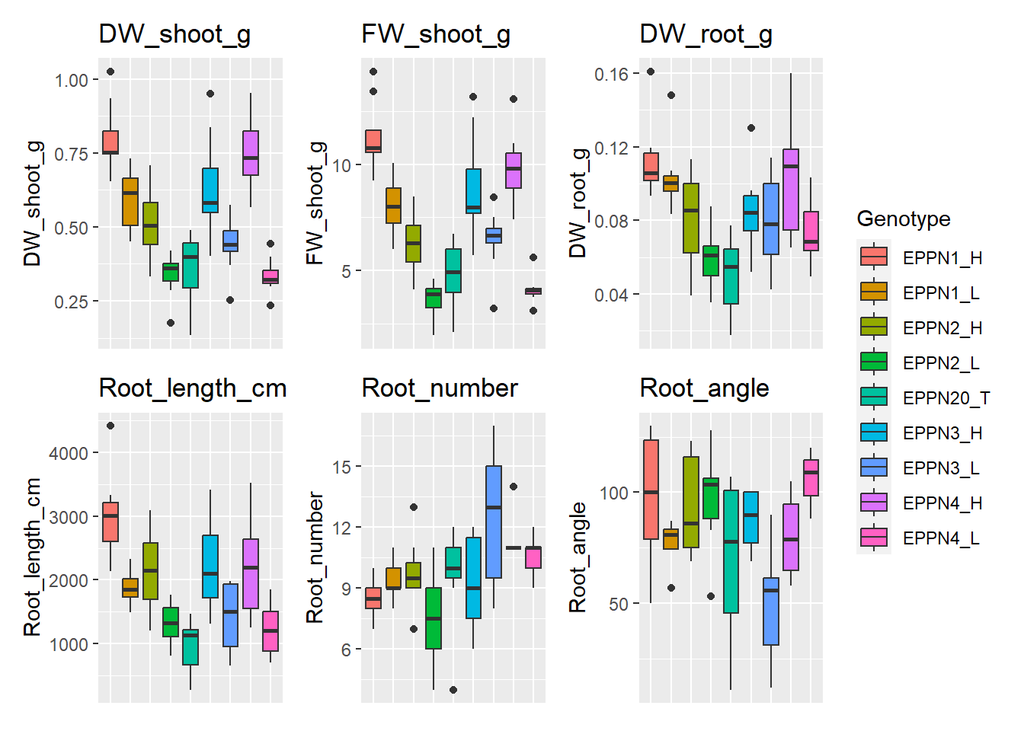

```r
create_boxplots(endpoint, variables, "Genotype")
```

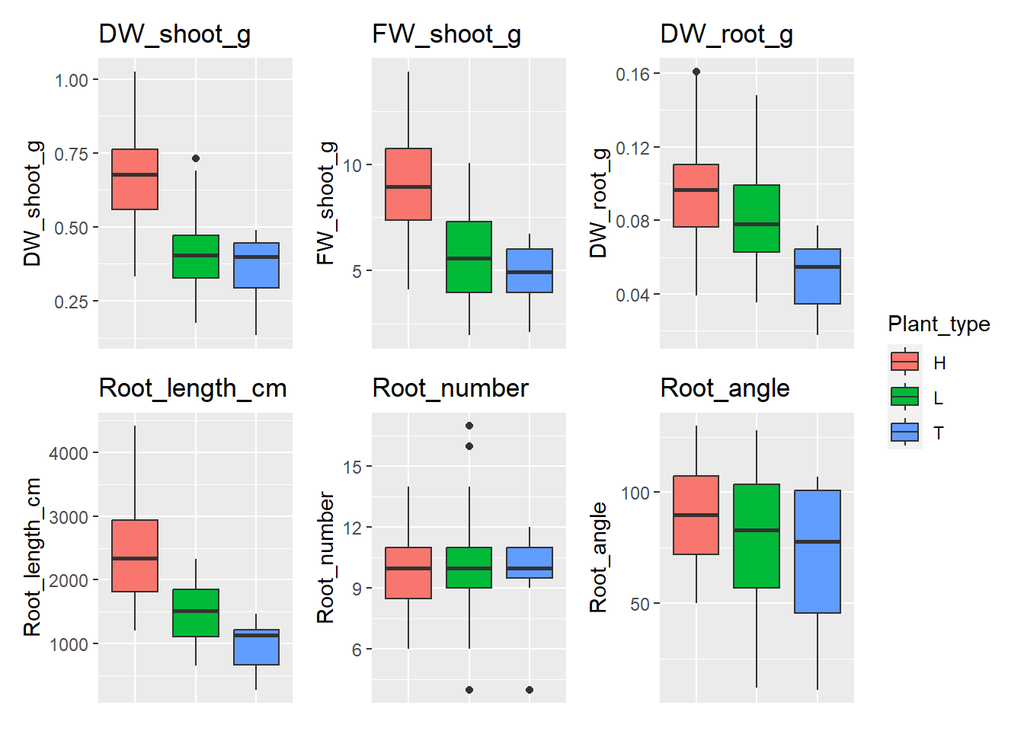

```r
create_boxplots(endpoint, variables, "Plant_type")
```

#### Correlation plots

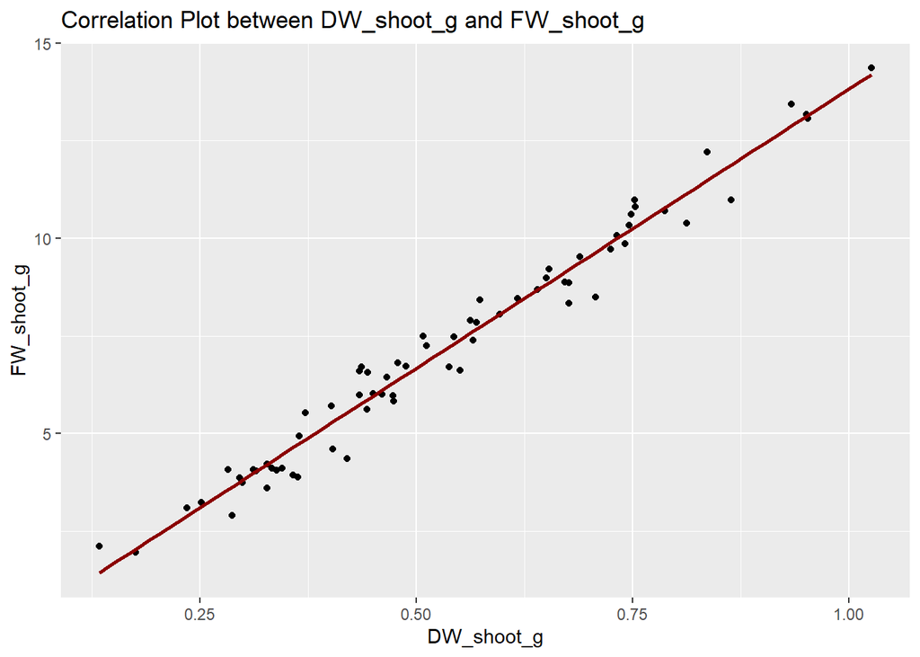

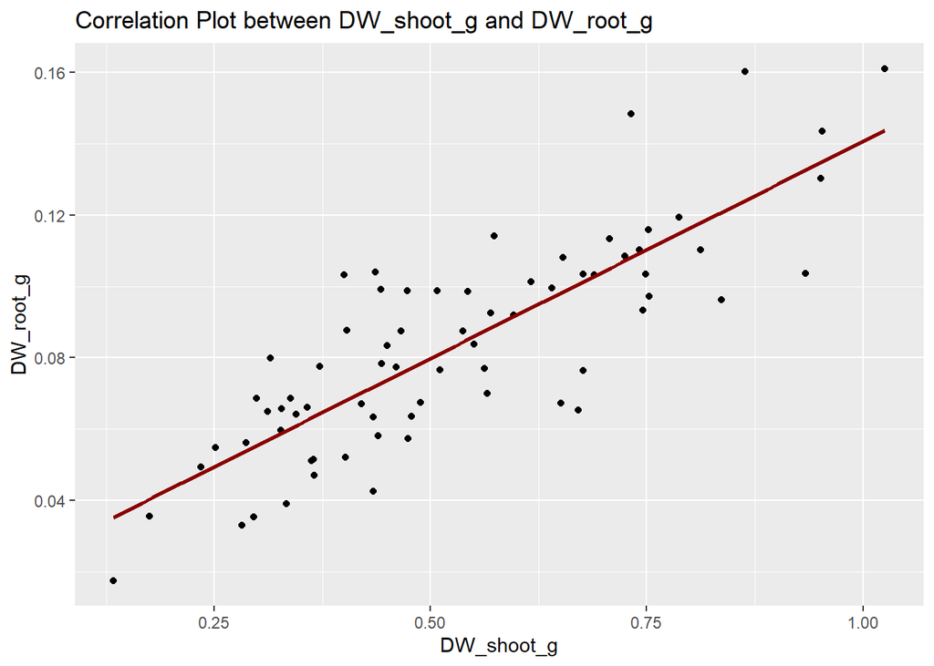

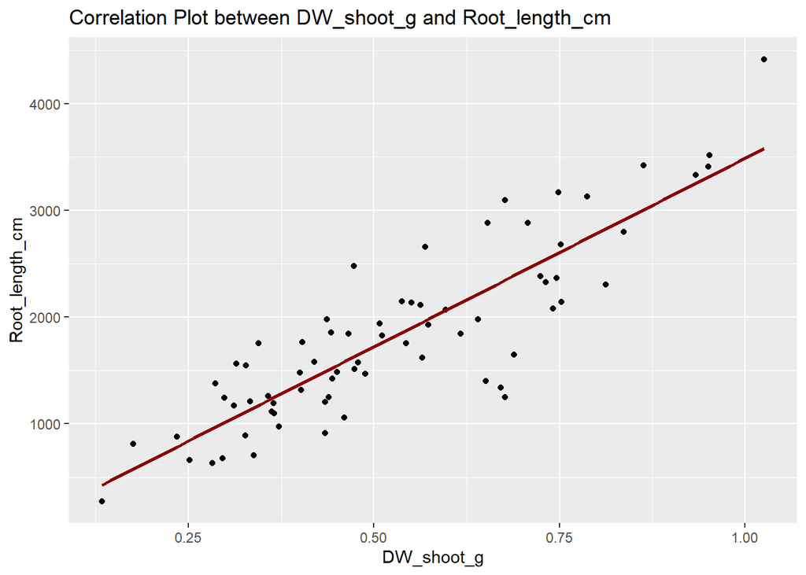

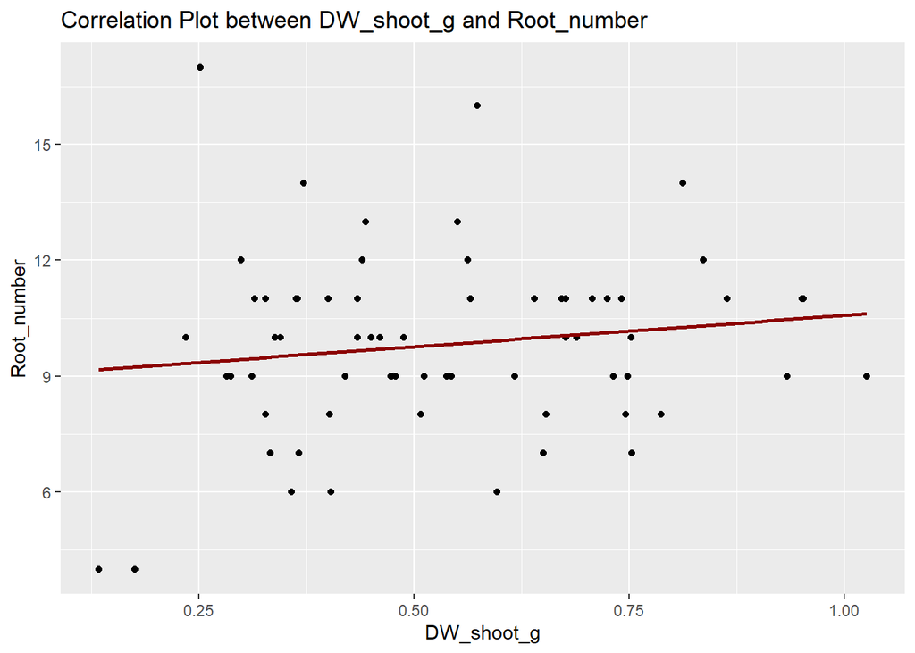

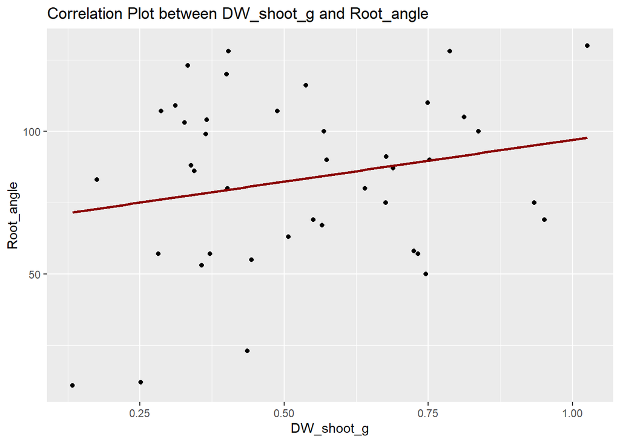

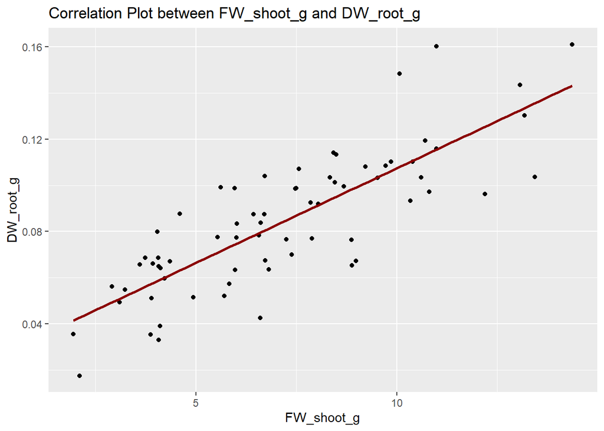

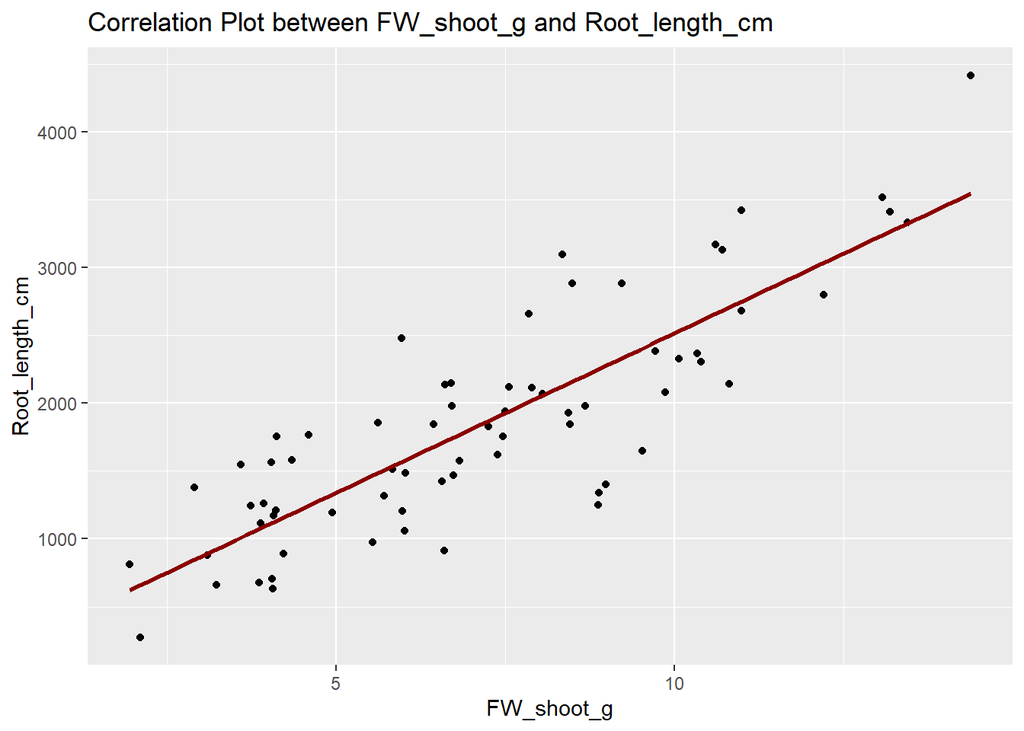

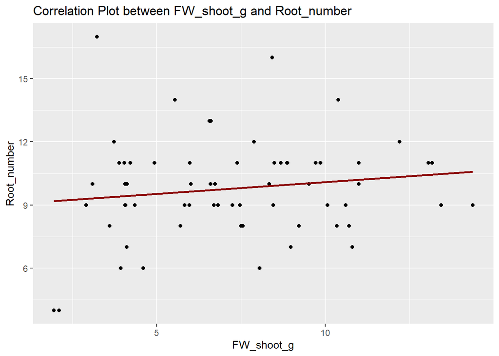

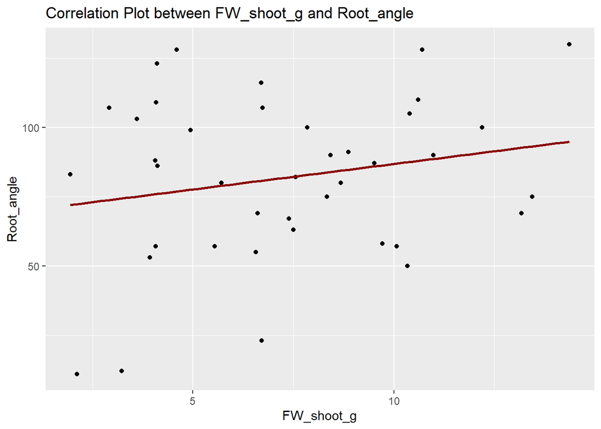

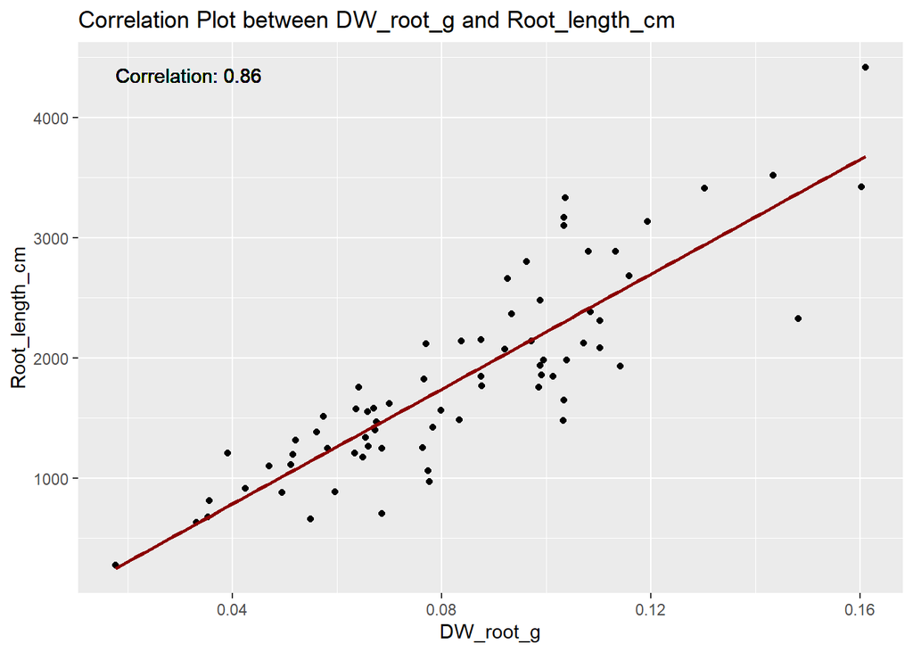

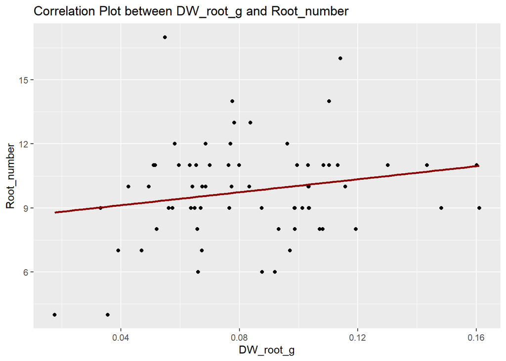

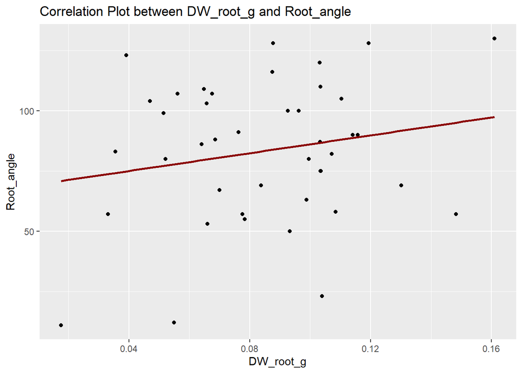

[3 more figures not shown]

```r
for (i in 1:(length(variables) - 1)) {
  for (j in (i + 1):length(variables)) {
    calculate_correlation_plot(endpoint, variables[i], variables[j])
  }
}
```

## B. Normality hypothesis and outlier detection

Test for normality hypothesis and plot density histogram. The red curve is the normal distribution, the blue dotted curve is the data density curve.

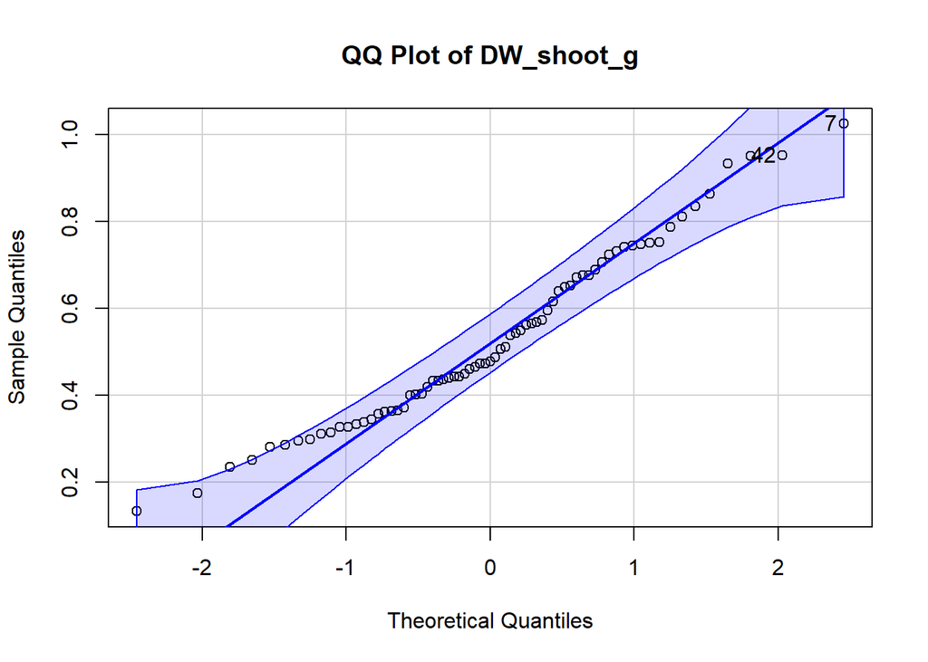

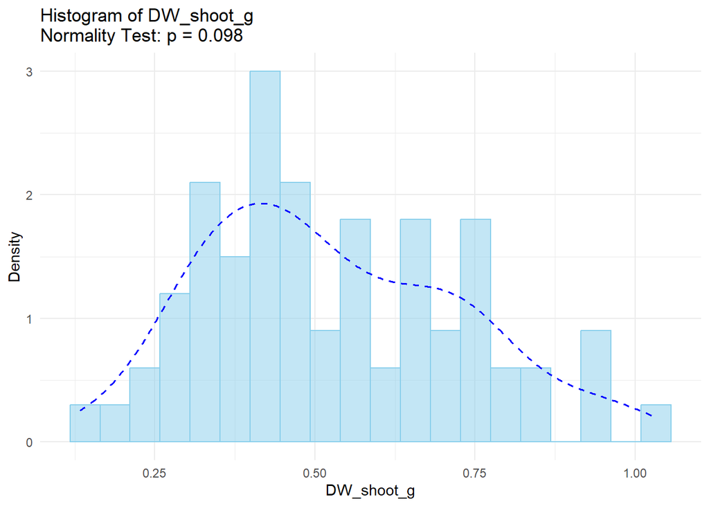

```
## [1]  7 42
```

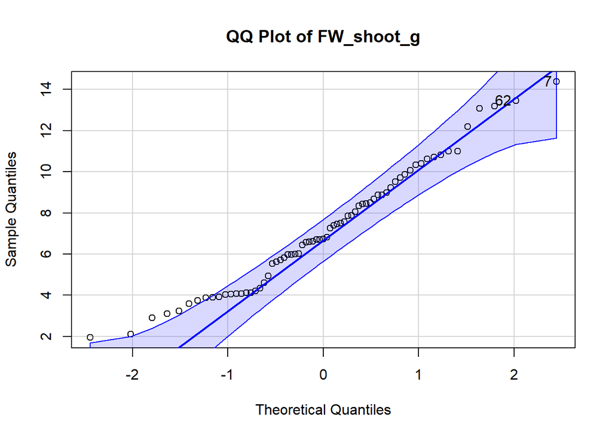

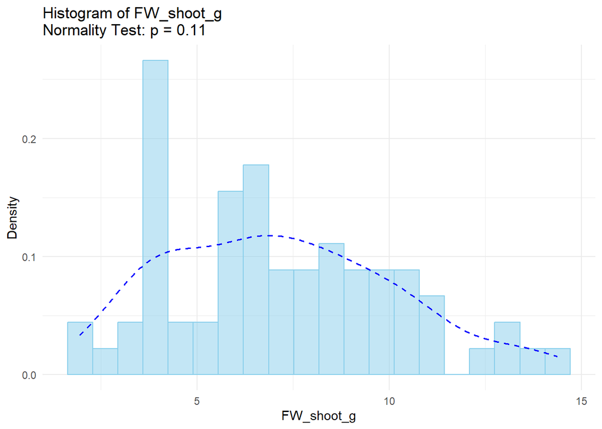

```
## [1]  7 62
```

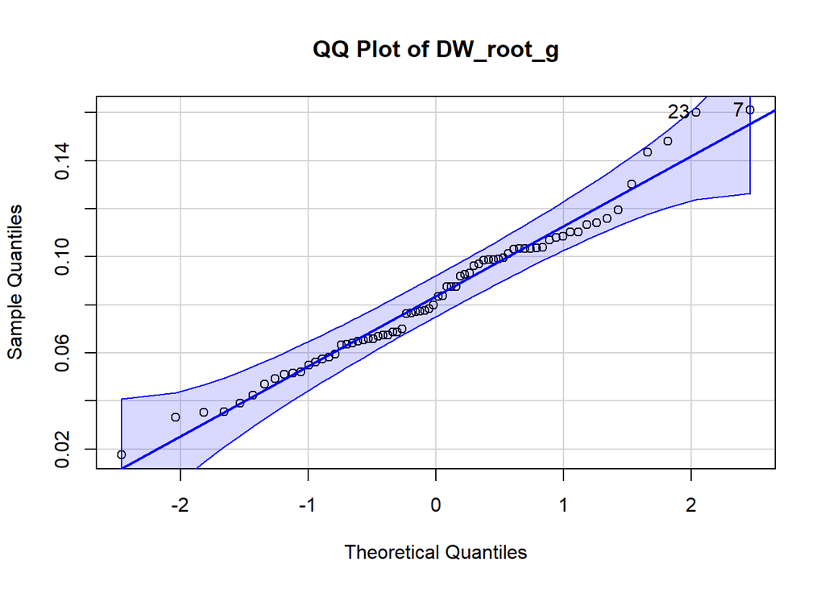

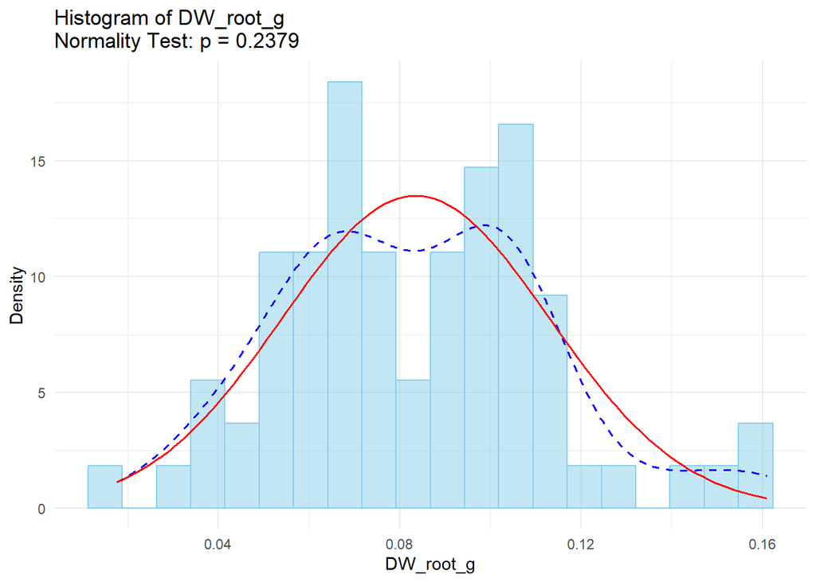

```
## [1]  7 23
```

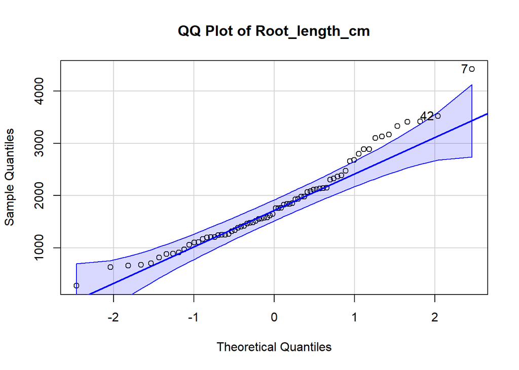

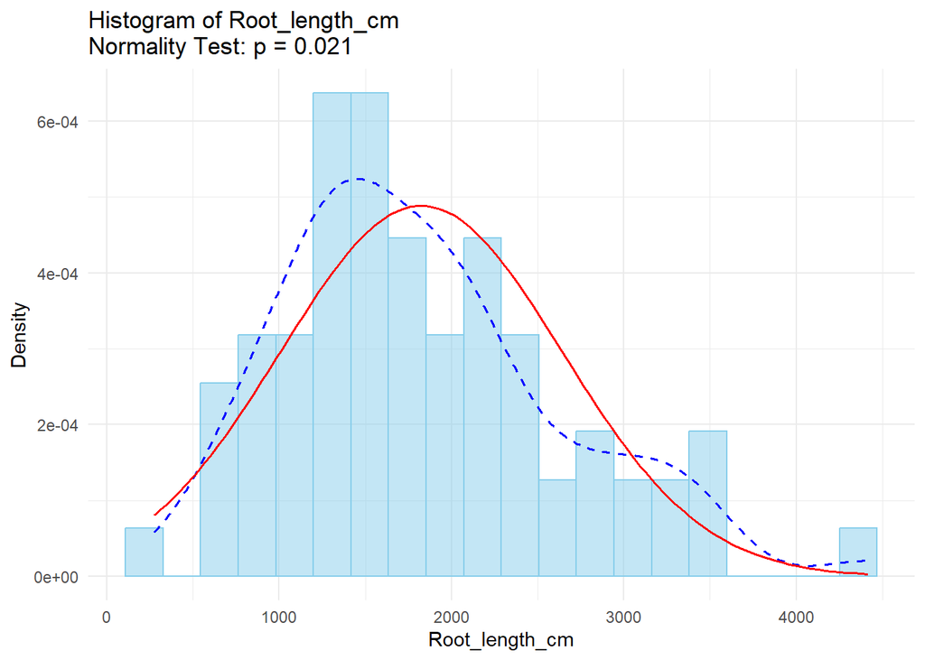

```
## [1]  7 42
```

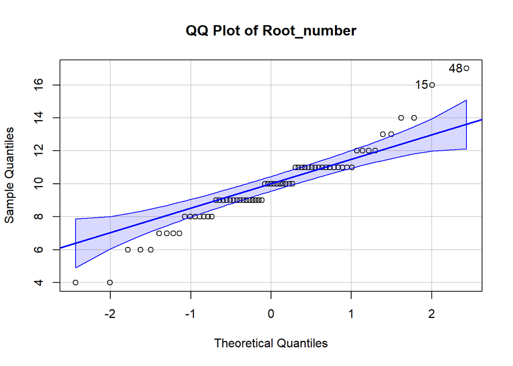

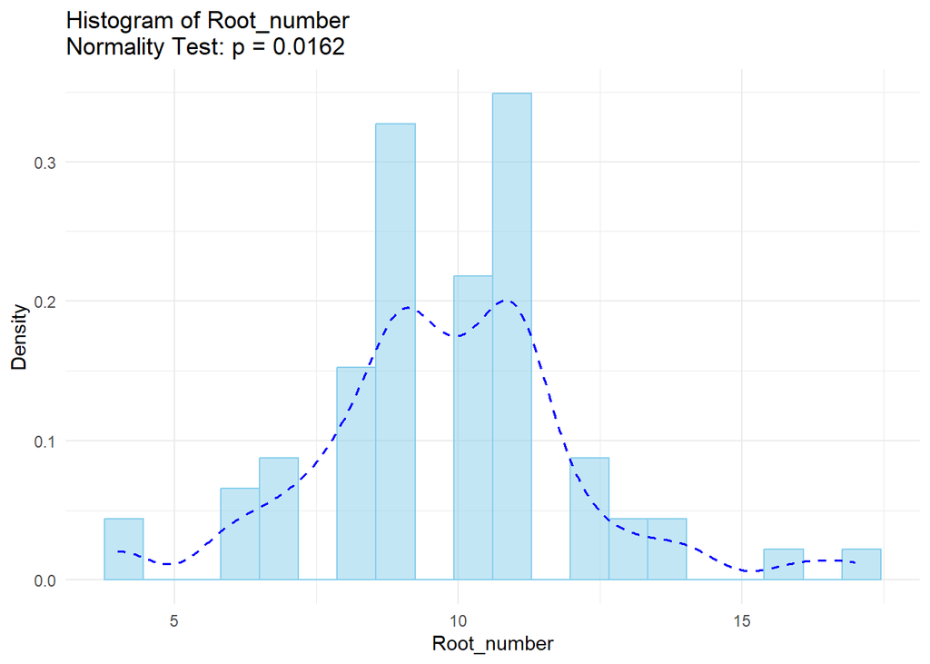

```
## [1] 48 15
```

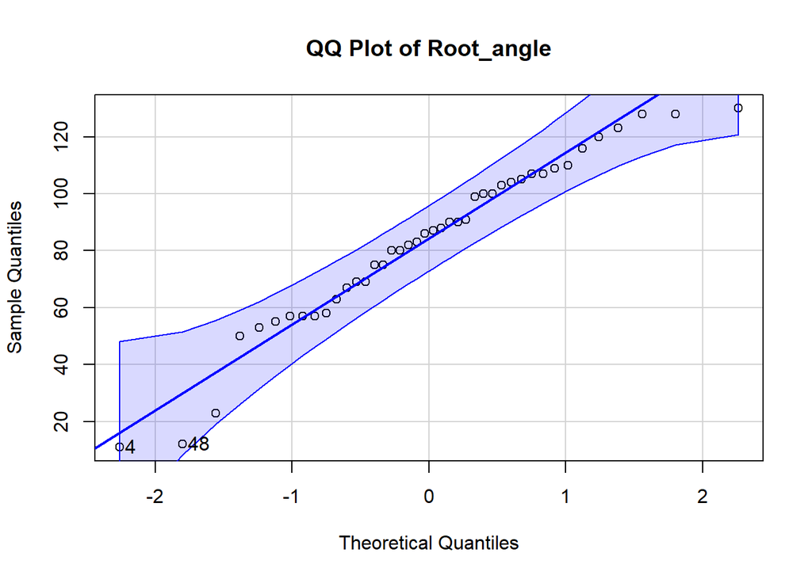

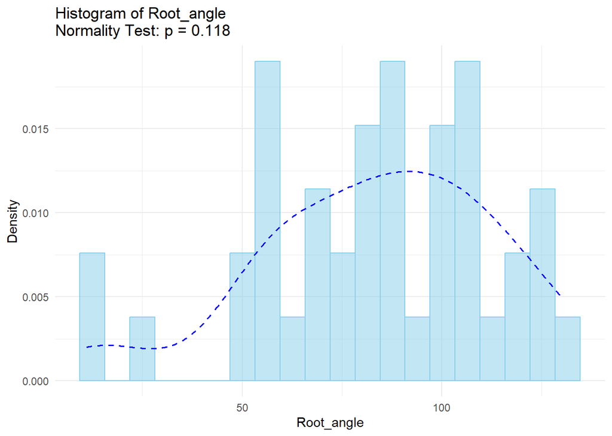

```
## [1]  4 48
```

```r
normality_results <- normality_test_histogram(endpoint)
```

Remove the outliers, replacing them with NULL values and normality visual verification.

The function detect_replace_ouliers_by_genotype checks for outlying values, using the Tukey method.

Then run the function on all variables of the dataset.

```r
endpoint_clean <- endpoint
# Run the function on the dataset for all the variables
endpoint_clean <- detect_replace_outliers_by_genotype(endpoint_clean)
```

### Boxplots after outlier detection

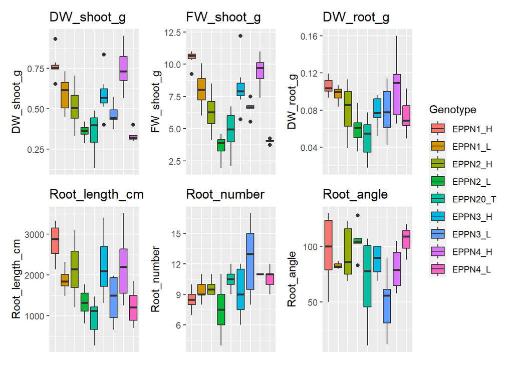

```r
create_boxplots(endpoint_clean, variables, "Genotype")
```

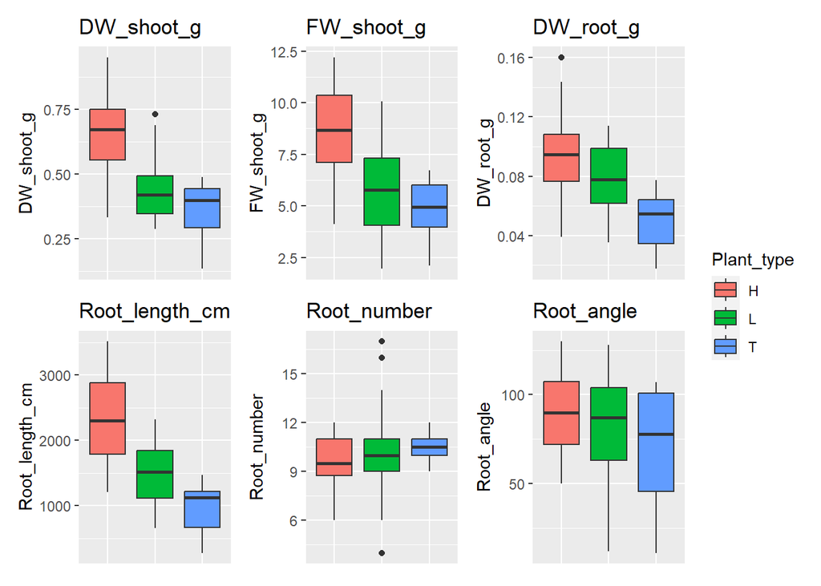

```r
create_boxplots(endpoint_clean, variables, "Plant_type")
```

### Violin and sina plots after outlier detection

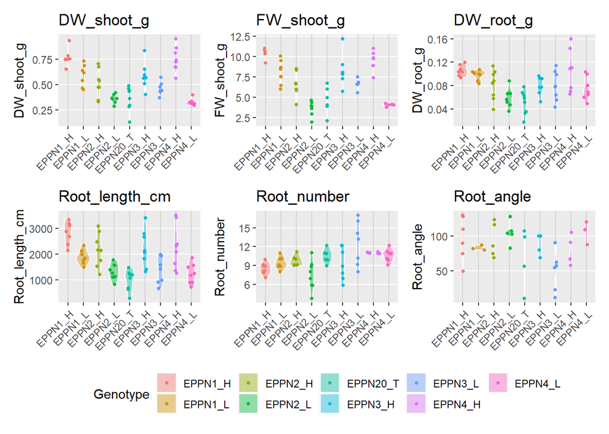

```r
create_violin_plots(endpoint_clean, variables, "Genotype")
```

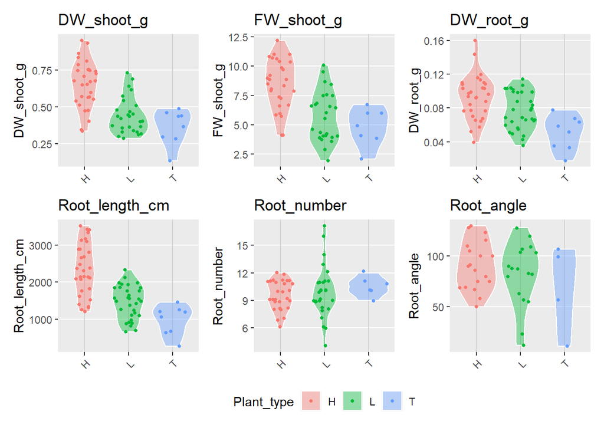

```r
create_violin_plots(endpoint_clean, variables, "Plant_type")
```

### Exploration statistics for the variables after outlier detection

```r
skim(endpoint_clean[variables])
```

Data summary

| Name | endpoint_clean[variables] |
| --- | --- |
| Number of rows | 72 |
| Number of columns | 6 |
| _______________________ |  |
| Column type frequency: |  |
| numeric | 6 |
| ________________________ |  |
| Group variables | None |

**Variable type: numeric**

| skim_variable | n_missing | complete_rate | mean | sd | p0 | p25 | p50 | p75 | p100 | hist |
| --- | --- | --- | --- | --- | --- | --- | --- | --- | --- | --- |
| DW_shoot_g | 7 | 0.90 | 0.53 | 0.18 | 0.13 | 0.37 | 0.49 | 0.68 | 0.95 | ▁▇▅▅▂ |
| FW_shoot_g | 11 | 0.85 | 6.88 | 2.53 | 1.95 | 4.35 | 6.71 | 8.87 | 12.20 | ▃▇▇▆▃ |
| DW_root_g | 3 | 0.96 | 0.08 | 0.03 | 0.02 | 0.06 | 0.08 | 0.10 | 0.16 | ▂▇▇▅▁ |
| Root_length_cm | 1 | 0.99 | 1788.26 | 761.09 | 275.45 | 1247.28 | 1645.89 | 2144.60 | 3518.73 | ▃▇▇▃▃ |
| Root_number | 9 | 0.88 | 9.81 | 2.18 | 4.00 | 9.00 | 10.00 | 11.00 | 17.00 | ▁▇▇▂▁ |
| Root_angle | 32 | 0.56 | 84.67 | 29.53 | 11.00 | 68.50 | 87.50 | 105.50 | 130.00 | ▂▃▆▇▆ |

```r
for (var in variables) {
  cat("\nSummary for:", var, "\n")
  endpoint_clean %>%
    group_by(Genotype) %>%
    summarize(mean    = mean(get(var), na.rm = TRUE),
              std.dev = sd(get(var), na.rm = TRUE),
              n_missing  = sum(is.na(get(var)))) %>%
    arrange(desc(mean)) %>%
    print(n = Inf)
}
```

```
##
## Summary for: DW_shoot_g
## # A tibble: 9 × 4
##   Genotype  mean std.dev n_missing
##   <fct>    <dbl>   <dbl>     <int>
## 1 EPPN1_H  0.768  0.0840         1
## 2 EPPN4_H  0.751  0.122          0
## 3 EPPN1_L  0.591  0.108          1
## 4 EPPN3_H  0.590  0.134          1
## 5 EPPN2_H  0.512  0.136          0
## 6 EPPN3_L  0.464  0.0642         1
## 7 EPPN20_T 0.362  0.119          0
## 8 EPPN2_L  0.360  0.0446         1
## 9 EPPN4_L  0.332  0.0361         2
##
## Summary for: FW_shoot_g
## # A tibble: 9 × 4
##   Genotype  mean std.dev n_missing
##   <fct>    <dbl>   <dbl>     <int>
## 1 EPPN1_H  10.4    0.639         2
## 2 EPPN4_H   9.44   1.18          1
## 3 EPPN3_H   8.28   2.00          1
## 4 EPPN1_L   8.03   1.42          0
## 5 EPPN3_L   6.62   0.631         2
## 6 EPPN2_H   6.27   1.65          0
## 7 EPPN20_T  4.82   1.59          1
## 8 EPPN4_L   4.03   0.176         3
## 9 EPPN2_L   3.60   0.909         1
##
## Summary for: DW_root_g
## # A tibble: 9 × 4
##   Genotype   mean std.dev n_missing
##   <fct>     <dbl>   <dbl>     <int>
## 1 EPPN1_H  0.106  0.00942         1
## 2 EPPN4_H  0.106  0.0342          0
## 3 EPPN1_L  0.0972 0.00860         1
## 4 EPPN2_H  0.0809 0.0254          0
## 5 EPPN3_L  0.0792 0.0251          0
## 6 EPPN3_H  0.0791 0.0159          1
## 7 EPPN4_L  0.0742 0.0188          0
```

[output cut: 29 more lines]

```
## 9 EPPN2_L   7.5    2.20          0
##
## Summary for: Root_angle
## # A tibble: 9 × 4
##   Genotype  mean std.dev n_missing
##   <fct>    <dbl>   <dbl>     <int>
## 1 EPPN4_L  106.    16.3          5
## 2 EPPN2_L  105     16.0          3
## 3 EPPN1_H   97.2   31.5          2
## 4 EPPN2_H   93.8   24.4          3
## 5 EPPN3_H   87.2   15.4          4
## 6 EPPN1_L   83      3.61         5
## 7 EPPN4_H   80.2   21.6          4
## 8 EPPN20_T  68.5   44.2          4
## 9 EPPN3_L   50     28.3          2
```

# 2. Exploration of the timeseries data

In this part, we look at the timeseries, S_timeseries and T_timeseries datasets, also using several functions, located in the functions.R script.

## Number of data observations per day for the traits of the timeseries datasets

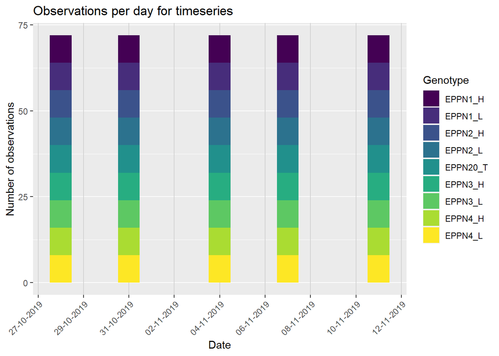

```r
h1 <- ggplot(timeseries, aes(x = Date)) +
  geom_bar(aes(fill = Genotype), position = "stack", width = 0.96) +
  scale_fill_viridis_d(option = "D") +
  labs(x = "Date", y = "Number of observations", title = "Observations per day for timeseries") +
  scale_y_continuous(breaks = seq(from = 0, to = 325, by = 25)) +
  scale_x_date(date_breaks = "2 days", date_labels = "%d-%m-%Y") +
  theme(axis.text.x = element_text(angle = 45, hjust = 1),
        panel.grid.major.x = element_line(color = "lightgray", size = 0.5),
        panel.grid.minor.x = element_blank())

h1
```